# Ciencia de Datos para Economistas

Clase 7: Estructuras de Datos

Autor/a

Afiliación

M.Sc. José Miguel Avendaño I.

Universidad Central de Venezuela- Escuela de Economía. 2025-1

Fecha de publicación

9 de abril de 2025

## Científicos de Datos 👨‍🔬 👩‍🔬

[figure not shown]

Sesgo del Superviviente

## Correlaciones Espúreas

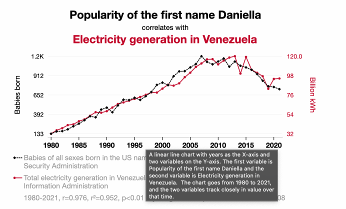

Correlaciones Espúreas

## Archivos:

- `.R`: script de R
- `.qmd` perteneciente al sistema de publicación quarto
- `.rds` : información comprimida de datos

## Vectores

- Se declaran con la función `c ()` que permite combinar elementos
- Los vectores deben contener elementos del mismo tipo, lo que se obtiene con la función `mode`
  - `mode (3)`
  - `mode (5)`
  - `mode ('palabras declaradas')` tiene distinto tipo de los anteriores
- Los elementos que los conforman poseen un orden ordenados
  - Vector `c (1,3,4,7)`

    != a vector `c (1,4,3,7)`

## Tipos de Vectores

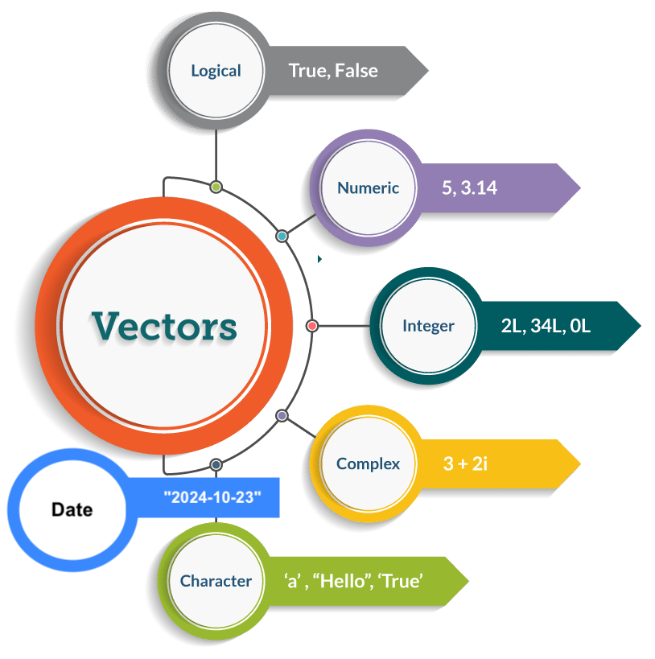

## Estructuras de Datos

Objeto

R

Ejemplo

vector atómico

`c(7)`

[figure not shown]

vector

`c('a', 'x', 'd')`

matriz

`matrix(1:8,`

`nrow=2,`

`ncol=4)`

## Estructuras de Datos 2

Objeto

R

Ejemplo

[figure not shown]

lista

ejem_lista<-list(el1=

c(‘a’,‘x’),

el2=c(1))

data frame

`mtcars`

tibble

`as_tibble(mtcars)`

## Tipos de de Objetos en R

`mode` : la forma en la que R almacena un objeto

`class` : la clase del objeto que estamos trabajando

Esto se abordará con algún detalle a lo largo del curso.

## Variables / Objetos

- Definición
- Creación
- Environment
- limpiar ambiente de trabajo

## Remover Objetos

- `rm(nombre_objeto)`
- `rm(list=ls())`

## Recursos Ayuda Paquetes:

- Vignettes:
  - ?? nombre paquete
  - Cran
- Cheat Sheets:
  - Discord, canal “Recursos disponibles”

    Cheat Sheet RStudio